# An Introduction to the samplr Package

Matt Schuelke

2018-11-25

The `samplr` package provides a number of functions for sampling from continuous distributions.

# projectq2a

The `projectq2a` function generates random deviates from a continuous random variable. The user supplies the probability density function of the continuous random variable, and the function utilizing rejection sampling to generate the deviates.

Rejection sampling is a type of exact simulation method in numerical analysis and works for any distrubtion in $\rm I\!R^m$ with a density. The idea of rejection sampling is to uniformly randomly sample the support and keep samples in the region under the graph of the density function.

Rejection sampling has two main assumptions:

1. $f(x) \le C$ (global maximum density)
2. $\exists$ a, b such that $P(a \le X \le b) = 1$ (finite)

## Uniform

Here is an example of using `projectq2a` to sample from the standard uniform distribution.

The uniform distribution has probability density function:

$$\text{pdf = }\begin{cases}\frac{1}{b - a} \text{for } x \in [a, b]\\0 \text{ otherwise}\end{cases}$$
We first generate a bunch of deviates and then plot their density in black. Then the true density is overlayed in red.

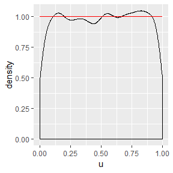

```r
df_uniform_samples <-
  data.frame(u = projectq2a(n = 10000,
                       pdf = dunif,
                       a = 0,
                       b = 1,
                       C = 1,
                       min = 0,
                       max = 1))

ggplot(df_uniform_samples, aes(x = u)) +
  geom_density() +
  stat_function(aes(x = 0), fun = dunif, args = list(min = 0, max = 1), color = "red")
```

## Beta

Here is an example of using `projectq2a` to sample from a beta distribution with both shape parameters equal to 2.

The beta distribution has probability density function:

$$\text{pdf = }\frac{x^{\alpha - 1}(1 - x)^{\beta - 1}}{B(\alpha, \beta)}$$

$$\text{where }B(\alpha, \beta) = \frac{\Gamma(\alpha)\Gamma(\beta)}{\Gamma(\alpha + \beta)}$$

We first generate a bunch of deviates and then plot their density in black. Then the true density is overlayed in red.

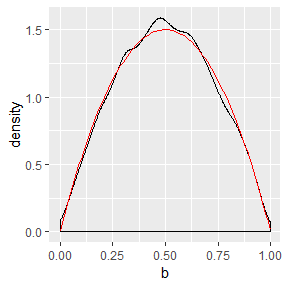

```r
df_beta_samples <-
  data.frame(b = projectq2a(n = 10000,
                       pdf = dbeta,
                       a = 0,
                       b = 1,
                       C = 1.5,
                       shape1 = 2,
                       shape2 = 2))

ggplot(df_beta_samples, aes(x = b)) +
  geom_density() +
  stat_function(aes(x = 0), fun = dbeta, args = list(shape1 = 2, shape2 = 2), color = "red")
```

## Custom Random Variable

Here is an example of using `projectq2a` to sample from a custom distribution.

In this case, the custom density function is that of a beta with shape parameters 2 and 5.

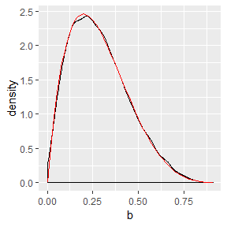

```r
dcustom <- function (x) {
  sapply(X = x,
         FUN = function(x) {
           ifelse(0 < x & x < 1,
                  (gamma(2+5)/(gamma(2)*gamma(5)))*(x^(2-1)*(1-x)^(5-1)),
                  0)
         })
}

df_custom_samples <-
  data.frame(b = projectq2a(n = 10000,
                       pdf = dcustom,
                       a = 0,
                       b = 1,
                       C = 2.5))

ggplot(df_custom_samples, aes(x = b)) +
  geom_density() +
  stat_function(aes(x = 0), fun = dcustom, color = "red")
```

# projectq3a

## Uniform on unit square

```r
d2dunif <- function(x, y, min = 0, max = 1) {
  if(min <= x && x <= max && min <= y && y <= max)
    (max - min)^(-2)
  else
    0
}

data.frame(x = sample(seq(0, 1, 0.01), 1000, replace = TRUE),
           y = sample(seq(0, 1, 0.01), 1000, replace = TRUE)) %>%
  mutate(z = d2dunif(x = x, y = y)) %>%
  plot_ly(., x = ~x, y = ~y, z = ~z) %>%
  add_markers(size = 0.25)
```

[interactive chart not shown]

```r
projectq3a(n = 1, pdf = d2dunif, a = 0, b = 1, C = 1)
```

```
#>           x         y
#> 1 0.2884076 0.1664578
```

## Custom Probability Density Function on a square

```r
d2dcirclecontour <- function(x, y) {
  if(-1 <= x && x <= 1 && -1 <= y && y <= 1)
    (3/8)*(x^2 + y^2)
  else
    0
}

data.frame(x = sample(seq(-1, 1, 0.01), 1000, replace = TRUE),
           y = sample(seq(-1, 1, 0.01), 1000, replace = TRUE)) %>%
  mutate(z = d2dcirclecontour(x = x, y = y)) %>%
  plot_ly(., x = ~x, y = ~y, z = ~z, color = ~z) %>%
  add_markers(size = 0.25)
```

[interactive chart not shown]

```r
projectq3a(n = 1, pdf = d2dcirclecontour, a = -1, b = 1, C = 0.75)
```

```
#>             x         y
#> 1 -0.09799382 0.5497423
```